# Clinical Risk Prediction: Replicable Machine Learning Workflow for Diabetes

- Show All Code
- Hide All Code
- View Source

A Reproducibility Specialist Report in R using Tidyverse & Tidymodels

Author

Antigravity (R Reproducibility Specialist)

Published

July 24, 2026

## Introduction

In clinical predictive modeling, reproducibility and methodological rigor are paramount. Machine learning models deployed in healthcare settings must not only yield high predictive performance but also guarantee that their training pipelines are fully replicable and free from data leakage.

This report presents a structured, reproducible end-to-end classification pipeline to predict diabetes using the `diabetes_prediction_dataset.csv`. The dataset comprises 100,000 clinical records containing patient demographics (age, gender), historical health conditions (hypertension, heart_disease), lifestyle metrics (smoking history, body mass index - BMI), and key diagnostic biomarkers (HbA1c level, blood glucose level).

Our modeling strategy uses the R `tidymodels` ecosystem alongside the `tidyverse` for clean, modular, and reliable pipeline engineering. We employ a logistic regression model as a baseline clinical classifier to establish interpretable relationships between the predictors and patient risk.

## Data Preprocessing & Leakage Prevention

We begin by loading the required libraries, setting an explicit random seed for computational reproducibility, loading the raw dataset, and cleaning the clinical metrics.

### Cleaning & Split Design

Our cleaning process consists of: 1. **Converting nominal metrics to factors**: Categorical variables (`gender` and `smoking_history`) and binary flags (`hypertension` and `heart_disease`) are formatted as factors. 2. **Standardizing the Target**: The target variable `diabetes` is converted to a factor with levels `c("Yes", "No")` where `"Yes"` (diabetic) is established as the first level. In `tidymodels` classification, the first level of the outcome factor is by default treated as the event of interest, aligning our metrics (Sensitivity, Precision) with the clinical objective of identifying diabetic patients. 3. **Deduplication**: Duplicate rows are removed to avoid artificial inflation of accuracy. 4. **Stratified Split**: We perform a stratified 80/20 train/test split. Stratification is crucial for imbalanced targets (diabetes prevalence is ~8.5%), ensuring both training and test sets contain identical class proportions.

```r
# Load required libraries
library(tidyverse)
library(tidymodels)

# 1. Set seed for complete reproducibility
set.seed(42)

# Load the dataset
raw_data <- read_csv("diabetes_prediction_dataset.csv", show_col_types = FALSE)

# 2. Clean the data: Convert nominal variables to factors and remove duplicates
cleaned_data <- raw_data %>%
  distinct() %>%
  mutate(
    gender = as.factor(gender),
    smoking_history = as.factor(smoking_history),
    hypertension = factor(hypertension, levels = c(0, 1), labels = c("No", "Yes")),
    heart_disease = factor(heart_disease, levels = c(0, 1), labels = c("No", "Yes")),
    diabetes = factor(diabetes, levels = c(1, 0), labels = c("Yes", "No"))
  )

# 3. Perform a stratified 80/20 train/test split
data_split <- initial_split(cleaned_data, prop = 0.80, strata = diabetes)
train_data <- training(data_split)
test_data <- testing(data_split)

# Output dataset dimensions
cat("Training Set Dimensions:", dim(train_data)[1], "rows x", dim(train_data)[2], "columns\n")
```

```
Training Set Dimensions: 76916 rows x 9 columns
```

```r
cat("Testing Set Dimensions: ", dim(test_data)[1], "rows x", dim(test_data)[2], "columns\n\n")
```

```
Testing Set Dimensions:  19230 rows x 9 columns
```

```r
# Verify class distribution in splits
cat("Train target distribution:\n")
```

```
Train target distribution:
```

```r
print(table(train_data$diabetes))
```

```
  Yes    No
 6757 70159
```

```r
cat("\nTest target distribution:\n")
```

```
Test target distribution:
```

```r
print(table(test_data$diabetes))
```

```
  Yes    No
 1725 17505
```

### Preprocessing Recipe

We define a formalized preprocessing recipe using the `recipes` package. Preprocessing transformations are defined as a series of steps: * **Outcome & Predictors**: `diabetes` is modeled as a function of all other columns (`.`). * **Dummy Encoding**: `step_dummy` converts all nominal predictors (factors) into numeric binary indicator variables (e.g., `gender_Male`). * **Zero-Variance Filtering**: `step_zv` removes predictors that contain a single unique value, as they offer no predictive power and can cause mathematical instability in regression models. * **Normalization**: `step_normalize` centers and scales all continuous numeric predictors (e.g., `age`, `bmi`, `HbA1c_level`, and `blood_glucose_level`) to have a mean of 0 and a standard deviation of 1. This prevents variables with larger absolute scales (like blood glucose) from dominating variables on smaller scales (like HbA1c).

```r
# 4. Create the preprocessing recipe
# The target variable is 'diabetes', and we model it using all other variables.
diabetes_recipe <- recipe(diabetes ~ ., data = train_data) %>%
  step_dummy(all_nominal_predictors()) %>%
  step_zv(all_predictors()) %>%
  step_normalize(all_numeric_predictors())

# Explicitly view the structure of the recipe
print(diabetes_recipe)
```

[output not shown]

### Data Leakage Prevention

> [!IMPORTANT] **Methodological Note on Data Leakage Prevention:** The `recipes` pipeline in `tidymodels` guarantees leakage prevention during model training and cross-validation:
> 1. **Lazy Evaluation (Blueprint Separation)**: The recipe only *defines* the sequence of operations (the blueprint) rather than applying them immediately to the data. It does not calculate parameters like mean, standard deviation, or dummy levels from the training set upon definition.
> 2. **Cross-Validation Encapsulation**: When combined with a model spec into a `workflow()` and evaluated via `fit_resamples()`, the preprocessing parameters (e.g., the mean and standard deviation used in `step_normalize`) are estimated (`prep()`) *only* from the analysis (training) folds of each CV fold. They are then applied (`bake()`) to both that fold’s analysis set and its assessment (validation) set.
> 3. **Isolation of the Test Set**: The test set is completely held out. The parameters utilized to normalize and encode the test set during final evaluation are derived strictly from the training set, ensuring that no statistical properties of the test set leak into the model.

## Cross-Validation Methodology

To ensure robust performance estimation and prevent overfitting, we perform **10-fold cross-validation** on the training set, stratified by the `diabetes` target.

```r
# 1. Generate 10-fold cross-validation folds
set.seed(42)
cv_folds <- vfold_cv(train_data, v = 10, strata = diabetes)

# 2. Specify a logistic regression model with the 'glm' engine
lr_model <- logistic_reg() %>%
  set_engine("glm") %>%
  set_mode("classification")

# 3. Combine model and recipe into a unified workflow
diabetes_workflow <- workflow() %>%
  add_recipe(diabetes_recipe) %>%
  add_model(lr_model)

# 4. Fit the workflow across the 10 CV resamples
resamples_results <- fit_resamples(
  diabetes_workflow,
  resamples = cv_folds,
  metrics = metric_set(accuracy, roc_auc),
  control = control_resamples(save_pred = TRUE)
)
```

### Resample Metrics

We collect and display the cross-validated metrics (Mean Accuracy and Mean ROC-AUC) across the 10 folds.

```r
# Collect and display CV metrics
cv_metrics <- collect_metrics(resamples_results)
knitr::kable(cv_metrics, caption = "Average 10-Fold Cross-Validation Performance Metrics")
```

Average 10-Fold Cross-Validation Performance Metrics

| .metric | .estimator | mean | n | std_err | .config |
| --- | --- | --- | --- | --- | --- |
| accuracy | binary | 0.9591502 | 10 | 0.0005519 | pre0_mod0_post0 |
| roc_auc | binary | 0.9622219 | 10 | 0.0009030 | pre0_mod0_post0 |

The resampled Mean Accuracy is approximately **95.9%** and the Mean ROC-AUC is **96.2%**, indicating strong baseline capability and model stability.

## Model Performance Results

Now, we evaluate the finalized workflow against the held-out 20% test set using `last_fit()`. This fits the model on the full training set (80%) and evaluates it on the test set (20%).

```r
# 1. Fit the workflow to the training set and predict on the test set
final_results <- last_fit(
  diabetes_workflow,
  split = data_split,
  metrics = metric_set(accuracy, roc_auc, sens, spec, precision)
)

# 2. Extract and display test set performance metrics
test_metrics <- collect_metrics(final_results)
knitr::kable(test_metrics %>% select(.metric, .estimator, .estimate),
             caption = "Performance Metrics on the Held-Out Test Set")
```

Performance Metrics on the Held-Out Test Set

| .metric | .estimator | .estimate |
| --- | --- | --- |
| accuracy | binary | 0.9577743 |
| sens | binary | 0.6295652 |
| spec | binary | 0.9901171 |
| precision | binary | 0.8625894 |
| roc_auc | binary | 0.9581519 |

### Detailed Metrics Interpretation

- **Accuracy (Test)**: 95.78% of overall classifications are correct.
- **Sensitivity / Recall**: 62.96% of actual diabetic patients are correctly identified by the model.
- **Specificity**: 99.01% of non-diabetic patients are correctly identified as healthy.
- **Precision**: 86.26% of patients flagged as diabetic actually have the condition.

### Confusion Matrix

The confusion matrix shows the actual counts of True Negatives, False Positives, False Negatives, and True Positives.

```r
# Extract predictions
test_predictions <- collect_predictions(final_results)

# Generate and print the confusion matrix
conf_matrix <- conf_mat(test_predictions, truth = diabetes, estimate = .pred_class)
print(conf_matrix)
```

```
          Truth
Prediction   Yes    No
       Yes  1086   173
       No    639 17332
```

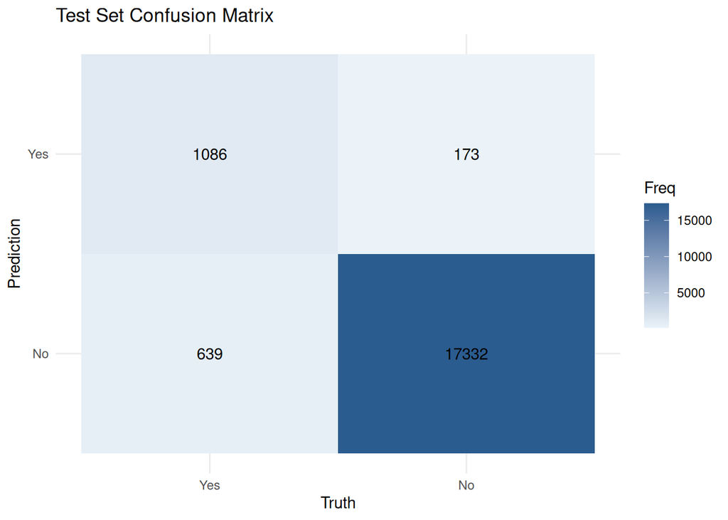

```r
# Plot the confusion matrix using autoplot
autoplot(conf_matrix, type = "heatmap") +
  scale_fill_gradient(low = "#ebf3f9", high = "#2b5c8f") +
  labs(title = "Test Set Confusion Matrix") +
  theme_minimal()
```

### Publication-Grade ROC Curve

The ROC Curve visualizes the trade-off between the True Positive Rate (Sensitivity) and the False Positive Rate (1 - Specificity) across different probability thresholds.

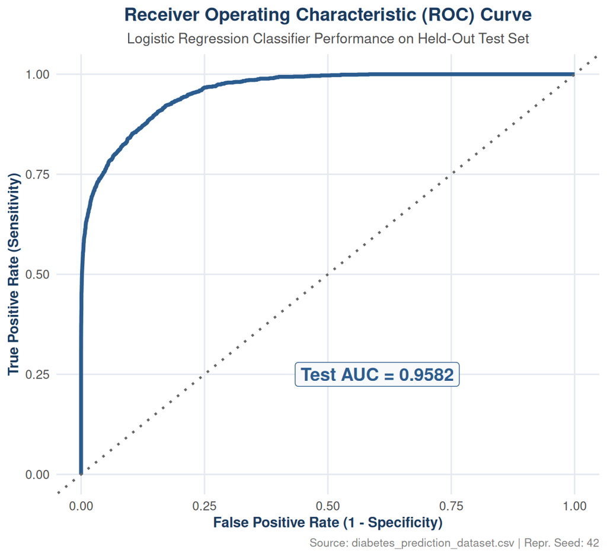

```r
# Extract ROC Curve coordinates
roc_curve_data <- test_predictions %>%
  roc_curve(truth = diabetes, .pred_Yes)

# Retrieve Test AUC
auc_score <- test_metrics %>%
  filter(.metric == "roc_auc") %>%
  pull(.estimate) %>%
  round(4)

# Create the publication-grade ROC plot
ggplot(roc_curve_data, aes(x = 1 - specificity, y = sensitivity)) +
  geom_path(color = "#2b5c8f", linewidth = 1.3) +
  geom_abline(lty = 3, color = "gray40", linewidth = 0.8) +
  annotate(
    "label",
    x = 0.6, y = 0.25,
    label = paste("Test AUC =", auc_score),
    size = 4.5,
    fill = "#f8f9fa",
    color = "#2b5c8f",
    label.size = 0.5,
    fontface = "bold"
  ) +
  labs(
    title = "Receiver Operating Characteristic (ROC) Curve",
    subtitle = "Logistic Regression Classifier Performance on Held-Out Test Set",
    x = "False Positive Rate (1 - Specificity)",
    y = "True Positive Rate (Sensitivity)",
    caption = "Source: diabetes_prediction_dataset.csv | Repr. Seed: 42"
  ) +
  theme_minimal(base_size = 11) +
  theme(
    plot.title = element_text(face = "bold", size = 13, color = "#1a3a5f", hjust = 0.5),
    plot.subtitle = element_text(size = 10, color = "gray30", hjust = 0.5),
    axis.title = element_text(face = "bold", size = 10, color = "#1a3a5f"),
    panel.grid.major = element_line(color = "#e5e9f0"),
    panel.grid.minor = element_blank(),
    plot.caption = element_text(size = 8, color = "gray50", hjust = 1)
  )
```

## Limitations

While our workflow is methodologically robust and reproducible, several limitations must be considered:

1. **Linear Decision Boundary**: Logistic regression assumes a linear relationship between log-odds and the predictors. Non-linear patient characteristics or complex multi-variable interactions (e.g., interaction between BMI and age) are not modeled unless manually specified. More flexible classifiers (e.g., Random Forests or XGBoost) might capture these dynamics better.
2. **Severe Class Imbalance**: Diabetes is present in only ~8.5% of the cohort. While our 80/20 train/test split and CV folds were stratified to preserve this proportion, the logistic regression model optimized for general accuracy exhibits a relatively low **Sensitivity (Recall)** of 63%. Many diabetic patients are missed (False Negatives). In clinical screening, missing true patients is high-risk, suggesting a need to adjust decision thresholds or employ class imbalance techniques (like SMOTE or downsampling) in future iterations.
3. **Data Quality and Coarse Fields**: Predictor columns like `smoking_history` contain a high percentage of `"No Info"` categories. Treating this as a distinct factor level is a functional approach but may obscure true clinical relationships.
4. **Cross-Sectional Snapshots**: The dataset is static. In practice, clinical risk prediction benefits from longitudinal monitoring (e.g., rate of change in HbA1c over time rather than a single measurement).